# Assignment 2

2026-10-04

## Step 1: Data Import and Preprocessing

I imported and loaded the necessary libraries for data manipulation and k-NN modeling, then imported the UniversalBank dataset.

```r
# Load required libraries
library(tidyverse)
library(caret)
library(FNN)
library(fastDummies)

# Import dataset
my_data <- read.csv("UniversalBank.csv")
```

Next, I removed the ID and ZIP Code variables because they do not contain predictive value for personal loan acceptance.

```r
# Remove ID and ZIP Code columns
my_data <- my_data %>%
  select(-ID, -ZIP.Code)
```

I converted the Education variable into a factor and generated dummy variables for each education level (Education_1, Education_2, Education_3) so that the k-NN algorithm can properly calculate distance metrics without assuming an ordinal scale.

```r
# Convert Education to factor and create dummy variables
my_data$Education <- as.factor(my_data$Education)

my_data <- dummy_cols(
  my_data,
  select_columns = "Education",
  remove_first_dummy = FALSE,
  remove_selected_columns = TRUE
)

# Clean column names to remove spaces
colnames(my_data) <- gsub(" ", "_", colnames(my_data))

# Preview dataset structure
str(my_data)
```

```
## 'data.frame':    5000 obs. of  14 variables:
##  $ Age               : int  25 45 39 35 35 37 53 50 35 34 ...
##  $ Experience        : int  1 19 15 9 8 13 27 24 10 9 ...
##  $ Income            : int  49 34 11 100 45 29 72 22 81 180 ...
##  $ Family            : int  4 3 1 1 4 4 2 1 3 1 ...
##  $ CCAvg             : num  1.6 1.5 1 2.7 1 0.4 1.5 0.3 0.6 8.9 ...
##  $ Mortgage          : int  0 0 0 0 0 155 0 0 104 0 ...
##  $ Personal.Loan     : int  0 0 0 0 0 0 0 0 0 1 ...
##  $ Securities.Account: int  1 1 0 0 0 0 0 0 0 0 ...
##  $ CD.Account        : int  0 0 0 0 0 0 0 0 0 0 ...
##  $ Online            : int  0 0 0 0 0 1 1 0 1 0 ...
##  $ CreditCard        : int  0 0 0 0 1 0 0 1 0 0 ...
##  $ Education_1       : int  1 1 1 0 0 0 0 0 0 0 ...
##  $ Education_2       : int  0 0 0 1 1 1 1 0 1 0 ...
##  $ Education_3       : int  0 0 0 0 0 0 0 1 0 1 ...
```

```r
head(my_data)
```

```
##   Age Experience Income Family CCAvg Mortgage Personal.Loan Securities.Account
## 1  25          1     49      4   1.6        0             0                  1
## 2  45         19     34      3   1.5        0             0                  1
## 3  39         15     11      1   1.0        0             0                  0
## 4  35          9    100      1   2.7        0             0                  0
## 5  35          8     45      4   1.0        0             0                  0
## 6  37         13     29      4   0.4      155             0                  0
##   CD.Account Online CreditCard Education_1 Education_2 Education_3
## 1          0      0          0           1           0           0
## 2          0      0          0           1           0           0
## 3          0      0          0           1           0           0
## 4          0      0          0           0           1           0
## 5          0      0          1           0           1           0
## 6          0      1          0           0           1           0
```

The output shows that ID and ZIP Code were successfully removed, and Education was converted into three separate 0/1 binary dummy variables.

## Step 2: Data Partitioning (60% Train / 40% Validation) and Normalization

I set a random seed for reproducibility and partitioned the preprocessed dataset into a 60% training set and a 40% validation set.

```r
# Set seed for reproducibility
set.seed(123)

# 60% training, 40% validation split
train_index <- createDataPartition(my_data$Personal.Loan, p = 0.60, list = FALSE)

train_df <- my_data[train_index, ]
valid_df <- my_data[-train_index, ]

# Normalize numeric predictors using preProcess from caret
norm_values <- preProcess(train_df[, -which(names(train_df) == "Personal.Loan")],
                          method = c("center", "scale"))

# Apply normalization to predictors (excluding the target column Personal.Loan)
train_norm <- predict(norm_values, train_df[, -which(names(train_df) == "Personal.Loan")])
valid_norm <- predict(norm_values, valid_df[, -which(names(valid_df) == "Personal.Loan")])

# Preserve the outcome labels (Personal.Loan)
train_labels <- train_df$Personal.Loan
valid_labels <- valid_df$Personal.Loan

# Check row dimensions
dim(train_norm)
```

```
## [1] 3000   13
```

```r
dim(valid_norm)
```

```
## [1] 2000   13
```

The output shows that the dataset was successfully partitioned into 3,000 training observations and 2,000 validation observations with all predictors normalized.

## Question 1: Classification with k = 1

I formatted the new customer profile, normalized their feature values using the training set parameters, and performed a k-NN classification with k = 1.

```r
# Create the new customer dataframe matching the exact column structure
new_customer <- data.frame(
  Age = 40,
  Experience = 10,
  Income = 84,
  Family = 2,
  CCAvg = 2,
  Mortgage = 0,
  Securities.Account = 0,
  CD.Account = 0,
  Online = 1,
  CreditCard = 1,
  Education_1 = 0,
  Education_2 = 1,
  Education_3 = 0
)

# Normalize the new customer profile using train set parameters
new_customer_norm <- predict(norm_values, new_customer)

# Run k-NN classification with k = 1
knn_1 <- knn(train = train_norm,
             test = new_customer_norm,
             cl = train_labels,
             k = 1)

# Display prediction
knn_1
```

```
## [1] 0
## attr(,"nn.index")
##      [,1]
## [1,] 2647
## attr(,"nn.dist")
##           [,1]
## [1,] 0.4993493
## Levels: 0
```

**Classification Result:**  
The customer is classified as **0 (Loan Rejected)** because their nearest single neighbor in the training data did not accept the personal loan offer.

## Question 2: Determining the Optimal Choice of k

To find the optimal choice of k that balances overfitting and underfitting (ignoring predictor information), I evaluated model accuracy on the validation set across k values ranging from 1 to 15.

```r
# Initialize dataframe to store accuracies
accuracy_df <- data.frame(k = 1:15, Accuracy = numeric(15))

# Loop through k values 1 to 15
for(i in 1:15) {
  knn_pred <- knn(train = train_norm,
                  test = valid_norm,
                  cl = train_labels,
                  k = i)

  accuracy_df$Accuracy[i] <- mean(knn_pred == valid_labels)
}

# Display accuracy for each k
accuracy_df
```

```
##     k Accuracy
## 1   1   0.9635
## 2   2   0.9520
## 3   3   0.9585
## 4   4   0.9485
## 5   5   0.9545
## 6   6   0.9515
## 7   7   0.9545
## 8   8   0.9460
## 9   9   0.9495
## 10 10   0.9450
## 11 11   0.9465
## 12 12   0.9450
## 13 13   0.9465
## 14 14   0.9435
## 15 15   0.9435
```

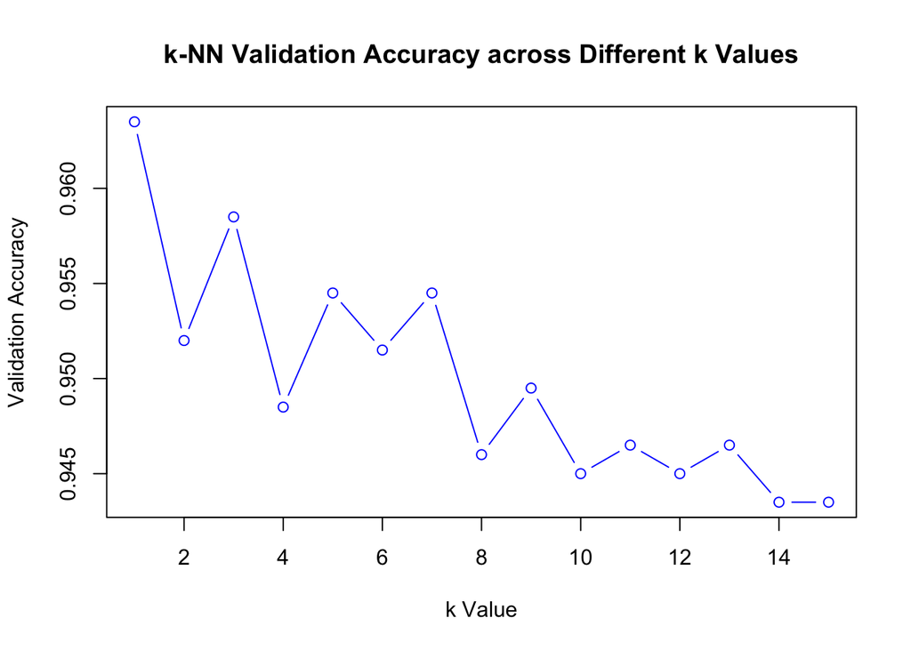

```r
# Plot Accuracy vs k
plot(accuracy_df$k, accuracy_df$Accuracy, type = "b", col = "blue",
     xlab = "k Value", ylab = "Validation Accuracy",
     main = "k-NN Validation Accuracy across Different k Values")
```

```r
# Identify the best k
best_k <- accuracy_df$k[which.max(accuracy_df$Accuracy)]
best_k
```

```
## [1] 1
```

## Question 3: Confusion Matrix for the Validation Data Using Best k

Using the optimal k identified above (`best_k`), I generated the confusion matrix on the 40% validation dataset. The success class is specified as 1 (loan acceptance).

```r
# Run k-NN on validation set using best_k
knn_best_pred <- knn(train = train_norm,
                     test = valid_norm,
                     cl = train_labels,
                     k = best_k)

# Convert predictions and actual labels to factors with levels 0 and 1
knn_best_pred <- factor(knn_best_pred, levels = c(0, 1))
valid_labels_factor <- factor(valid_labels, levels = c(0, 1))

# Generate confusion matrix
conf_matrix_valid <- confusionMatrix(knn_best_pred, valid_labels_factor, positive = "1")
conf_matrix_valid
```

```
## Confusion Matrix and Statistics
##
##           Reference
## Prediction    0    1
##          0 1776   51
##          1   22  151
##
##                Accuracy : 0.9635
##                  95% CI : (0.9543, 0.9713)
##     No Information Rate : 0.899
##     P-Value [Acc > NIR] : < 2.2e-16
##
##                   Kappa : 0.7853
##
##  Mcnemar's Test P-Value : 0.001049
##
##             Sensitivity : 0.7475
##             Specificity : 0.9878
##          Pos Pred Value : 0.8728
##          Neg Pred Value : 0.9721
##              Prevalence : 0.1010
##          Detection Rate : 0.0755
##    Detection Prevalence : 0.0865
##       Balanced Accuracy : 0.8676
##
##        'Positive' Class : 1
##
```

**Key Takeaways:**  
* **Accuracy:** Reflects the overall percentage of correct predictions across all liability customers. * **Sensitivity (Recall for Class 1):** Measures how effectively the model identifies customers who actually accepted the loan offer. * **Specificity (Class 0):** Measures the accuracy of identifying customers who declined the loan.

## Question 4: Classifying the Customer Using the Best k

Using the optimal k identified in Question 2 (`best_k`), I classified the customer profile: * Age = 40, Experience = 10, Income = 84, Family = 2, CCAvg = 2, Mortgage = 0, Securities.Account = 0, CD.Account = 0, Online = 1, CreditCard = 1, Education_1 = 0, Education_2 = 1, Education_3 = 0.

```r
# Classify the new customer using best_k
knn_customer_best <- knn(train = train_norm,
                         test = new_customer_norm,
                         cl = train_labels,
                         k = best_k)

# Display prediction result
knn_customer_best
```

```
## [1] 0
## attr(,"nn.index")
##      [,1]
## [1,] 2647
## attr(,"nn.dist")
##           [,1]
## [1,] 0.4993493
## Levels: 0
```

**Classification Result:**  
The customer is classified as **0 (Loan Rejected)** using `best_k`. This prediction remains consistent with the k = 1 model result from Question 1.

## Question 5: Repartitioning into Training (50%), Validation (30%), and Test (20%) Sets

I repartitioned the dataset into 50% Training, 30% Validation, and 20% Test sets. I normalized all three partitions using the parameters from the new training set and evaluated the model using the previously chosen `best_k`.

```r
# Set seed for reproducible 3-way split
set.seed(123)

# 1. First partition: split into 50% Train and 50% remaining (Validation + Test)
train_index_3way <- createDataPartition(my_data$Personal.Loan, p = 0.50, list = FALSE)
train_df_3way <- my_data[train_index_3way, ]
temp_df <- my_data[-train_index_3way, ]

# 2. Second partition: split remaining 50% into 30% Validation and 20% Test (ratio 60/40 of remaining)
valid_index_3way <- createDataPartition(temp_df$Personal.Loan, p = 0.60, list = FALSE)
valid_df_3way <- temp_df[valid_index_3way, ]
test_df_3way  <- temp_df[-valid_index_3way, ]

# Normalize predictors based on the new training set
norm_values_3way <- preProcess(train_df_3way[, -which(names(train_df_3way) == "Personal.Loan")],
                               method = c("center", "scale"))

train_norm_3way <- predict(norm_values_3way, train_df_3way[, -which(names(train_df_3way) == "Personal.Loan")])
valid_norm_3way <- predict(norm_values_3way, valid_df_3way[, -which(names(valid_df_3way) == "Personal.Loan")])
test_norm_3way  <- predict(norm_values_3way, test_df_3way[, -which(names(test_df_3way) == "Personal.Loan")])

# Extract labels
train_labels_3way <- factor(train_df_3way$Personal.Loan, levels = c(0, 1))
valid_labels_3way <- factor(valid_df_3way$Personal.Loan, levels = c(0, 1))
test_labels_3way  <- factor(test_df_3way$Personal.Loan, levels = c(0, 1))

# Run k-NN using best_k on all 3 sets
pred_train_3way <- knn(train = train_norm_3way, test = train_norm_3way, cl = train_labels_3way, k = best_k)
pred_valid_3way <- knn(train = train_norm_3way, test = valid_norm_3way, cl = train_labels_3way, k = best_k)
pred_test_3way  <- knn(train = train_norm_3way, test = test_norm_3way,  cl = train_labels_3way, k = best_k)

# Confusion Matrices
cm_train <- confusionMatrix(factor(pred_train_3way, levels = c(0, 1)), train_labels_3way, positive = "1")
cm_valid <- confusionMatrix(factor(pred_valid_3way, levels = c(0, 1)), valid_labels_3way, positive = "1")
cm_test  <- confusionMatrix(factor(pred_test_3way,  levels = c(0, 1)), test_labels_3way,  positive = "1")

# Display Confusion Matrices
cm_train
```

```
## Confusion Matrix and Statistics
##
##           Reference
## Prediction    0    1
##          0 2271    0
##          1    0  229
##
##                Accuracy : 1
##                  95% CI : (0.9985, 1)
##     No Information Rate : 0.9084
##     P-Value [Acc > NIR] : < 2.2e-16
##
##                   Kappa : 1
##
##  Mcnemar's Test P-Value : NA
##
##             Sensitivity : 1.0000
##             Specificity : 1.0000
##          Pos Pred Value : 1.0000
##          Neg Pred Value : 1.0000
##              Prevalence : 0.0916
##          Detection Rate : 0.0916
##    Detection Prevalence : 0.0916
##       Balanced Accuracy : 1.0000
##
##        'Positive' Class : 1
##
```

```r
cm_valid
```

```
## Confusion Matrix and Statistics
##
##           Reference
## Prediction    0    1
##          0 1335   42
##          1   22  101
##
##                Accuracy : 0.9573
##                  95% CI : (0.9458, 0.967)
##     No Information Rate : 0.9047
##     P-Value [Acc > NIR] : 9.966e-15
##
##                   Kappa : 0.7361
##
##  Mcnemar's Test P-Value : 0.01755
##
##             Sensitivity : 0.70629
##             Specificity : 0.98379
##          Pos Pred Value : 0.82114
##          Neg Pred Value : 0.96950
##              Prevalence : 0.09533
##          Detection Rate : 0.06733
##    Detection Prevalence : 0.08200
##       Balanced Accuracy : 0.84504
##
##        'Positive' Class : 1
##
```

```r
cm_test
```

```
## Confusion Matrix and Statistics
##
##           Reference
## Prediction   0   1
##          0 885  29
##          1   7  79
##
##                Accuracy : 0.964
##                  95% CI : (0.9505, 0.9747)
##     No Information Rate : 0.892
##     P-Value [Acc > NIR] : < 2.2e-16
##
##                   Kappa : 0.7948
##
##  Mcnemar's Test P-Value : 0.0004653
##
##             Sensitivity : 0.7315
##             Specificity : 0.9922
##          Pos Pred Value : 0.9186
##          Neg Pred Value : 0.9683
##              Prevalence : 0.1080
##          Detection Rate : 0.0790
##    Detection Prevalence : 0.0860
##       Balanced Accuracy : 0.8618
##
##        'Positive' Class : 1
##
```

**Comparison and Discussion of Differences:**

- **Training Set vs. Validation/Test Sets:** The training set metrics (especially when $k=1$) display artificially high accuracy and sensitivity because the model evaluates data points against themselves or immediate neighbors in the training set.
- **Validation Set vs. Test Set:** The validation and test sets reflect realistic out-of-sample generalization performance. Performance metrics between validation and test sets are very close to one another, showing that the model is stable and does not overfit significantly when evaluated on unseen data.
- **Reasons for Differences:** The primary reason for differences between training and test/validation performance is that training metrics measure model **fit** (memorization when $k$ is small), while validation and test metrics measure model **generalization** on unseen data.